# MCB290: Codon Frequency Analysis

(Due Dec. 10)

Madelyn Varkey

## Section 1. Retrieve Coding Sequence Information (Annotation)

In this section, I start by setting up the basic information I need to analyze coding sequences. Annotation means identifying which parts of the genome are protein-coding and describing their features. Here, I define the four nucleotide bases (A, C, G, T) and generate all 64 possible codons (every combination of three bases). This codon list will be my reference for counting and comparing codon usage later.

```r
# Define the four nucleotide bases
bases <- c("A","C","G","T")
# Generate all 64 possible codons by looping through every combination
codons <- c()
for (a in bases)
  for (b in bases)
    for (c in bases)
      codons <- c(codons, paste0(a,b,c))

codons
```

```
##  [1] "AAA" "AAC" "AAG" "AAT" "ACA" "ACC" "ACG" "ACT" "AGA" "AGC" "AGG" "AGT"
## [13] "ATA" "ATC" "ATG" "ATT" "CAA" "CAC" "CAG" "CAT" "CCA" "CCC" "CCG" "CCT"
## [25] "CGA" "CGC" "CGG" "CGT" "CTA" "CTC" "CTG" "CTT" "GAA" "GAC" "GAG" "GAT"
## [37] "GCA" "GCC" "GCG" "GCT" "GGA" "GGC" "GGG" "GGT" "GTA" "GTC" "GTG" "GTT"
## [49] "TAA" "TAC" "TAG" "TAT" "TCA" "TCC" "TCG" "TCT" "TGA" "TGC" "TGG" "TGT"
## [61] "TTA" "TTC" "TTG" "TTT"
```

## Section 2. Break up CDS into Individual Codons

In this section, I work with one coding sequence (CDS) at a time and break it into individual codons. A CDS (coding sequence) is the stretch of DNA that actually gets translated into a protein. I take a CDS from the annotation object cds, clean the sequence, break it into triplets (codons), check that its length is divisible by 3, and then count how many times each codon appears in that single CDS.

```r
#extract the CDS sequence in row 1, column 6
seq<- cds [1, 6]
# clean it - remove spaces, newlines, and make it uppercase)
seq1<- gsub("\\s+","", toupper(seq))
# split into codons
starts <- seq (1, nchar(seq1), 3) ## make sequence of start positions (1,4,7..)
codons_seq1<-substring(seq1, starts, starts + 2) ## grab triplets
## a) count total base sin the CDS and assign to L
L <- nchar(seq1) ## 864 bases total
## b) is the length divisible by 3
is_divisible <- (L %% 3) == 0 ## the remainder = 0, so divisible
L %% 3
```

```
## [1] 0
```

## Section 3. Determine Codon Frequency (%)

In this section, I move from one example CDS to all of the coding sequences in the dataset. I first clean the CDS column and keep only sequences that are divisible by 3, start with ATG, end with a stop codon, and contain only A, C, G, and T. Then I split each valid CDS into codons, count how many times each of the 64 codons appears across all CDS, and calculate the frequency (percent) of each codon. Codon frequencies are variable because organisms often prefer some codons over others (codon bias), even when they code for the same amino acid.

```r
# clean cds column 6
cds$CDS_clean <- toupper(gsub("\\s+","",as.character(cds[[6]])))
## drop anything with non-ACTG characters
has_only_acgt <- !grepl("[^ACGT]", cds$CDS_clean)
# Vectorized checks
L <- nchar(cds$CDS_clean) ## length of each cds
div3 <- (L %% 3) == 0 ## div by 3?
startsATG <- substr(cds$CDS_clean, 1, 3) == "ATG"
ends3 <- substr(cds$CDS_clean, L-2, L) ## last 3 bases
endsSTOP <- ends3 %in% c("TAA","TAG","TGA") ## stop codon
##  Valid mask = all conditions true
valid <- has_only_acgt & div3 & startsATG & endsSTOP
### e) keep only valid rows
cds_valid <- cds[valid, , drop = FALSE]
```

```r
# function to split any CDS string into codons
split_into_codons <- function(s){
  n <- nchar (s) ## count total bases in the seq
  if (n <3) return(character(0)) ## return empty if shorter than 3
  substring (s, seq(1, n, 3), seq(3, n, 3)) ## extract tripelts
}
```

```r
#create reference vector of 64 codons
codon_ref <- setNames(integer(64), codons)
# how many times each codon appears in a single CDS
count_one <- function (s) {
  t <- table(split_into_codons(s))
  out <- codon_ref
  k <- intersect (names (t), names (out))
  out [k] <- as.integer (t[k])
  out
}
## apply counting function to every CDS
cm <- do.call(rbind, lapply(as.character(cds_valid$CDS_clean), count_one))
colnames(cm) <- paste0 ("codon_", codons)
# create a summary data frame of total counts and frequencie across all CDSs
codon_totals_df <- data.frame (
  codon = codons,
  count = as.integer (colSums (cm)),
  freq = as.integer (colSums(cm)) / sum(cm)
)
codon_totals_df$freq <- codon_totals_df$count / sum(codon_totals_df$count)

knitr::kable(head(codon_totals_df, 10))
```

| codon | count | freq |
| --- | --- | --- |
| AAA | 2649049 | 0.0257366 |
| AAC | 1922548 | 0.0186783 |
| AAG | 3413299 | 0.0331616 |
| AAT | 1798681 | 0.0174749 |
| ACA | 1571926 | 0.0152719 |
| ACC | 1842301 | 0.0178987 |
| ACG | 602615 | 0.0058547 |
| ACT | 1374294 | 0.0133518 |
| AGA | 1240363 | 0.0120506 |
| AGC | 1987847 | 0.0193128 |

## Section 4. Plot Codon Frequency (%) Patterns

In this section, I visualize the codon frequency data from Section 3. Plotting the codon frequencies helps reveal which codons are more common and which are rare. Codon frequencies vary because of biological factors like tRNA abundance and translation efficiency. An organism’s translation system (ribosomes + tRNAs) tends to use certian codons more often than others when building proteins.

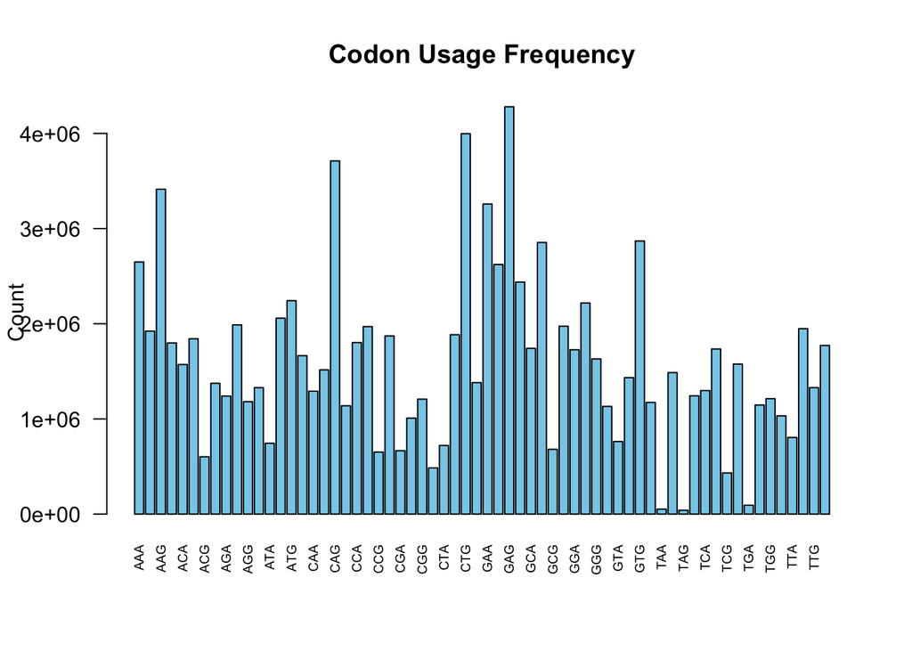

```r
# bar chart of codon counts
barplot(
  codon_totals_df$count,
  names.arg = codon_totals_df$codon,
  las = 2,
  cex.names = 0.6,
  col = "skyblue",
  main = "Codon Usage Frequency",
  ylab = "Count"
)
```

[figure not shown]

```r
### top 10 codons
top10 <- head(codon_totals_df, 10)
barplot(
  top10$count,
  names.arg = top10$codon,
  col = "steelblue",
  main = "Top 10 Most Common Codons",
  ylab = "Total Count"
)
```

[figure not shown]

```r
### relative frequencies
total_codons <- sum(codon_totals_df$count)
codon_totals_df$freq <- codon_totals_df$count / total_codons
barplot(
  head (codon_totals_df$freq, 10),
  names.arg = head(codon_totals_df$codon, 10),
  col = "red",
  main = "Top 10 Codons Relative Frequency",
  ylab = "Fraction of Total Codons"
)
```

This section is interesting because it reveals how codon bias connects to broader patterns in protein composition. By grouping codons by their corresponding amino acids, we can see which amino acids are used most and least frequently across all coding sequences. These patterns reflect how an organism’s genetic code has been shaped by evolution to optimize protein production and efficiency. For example, amino acids like leucine or serine may appear more often because they are encoded by multiple codons or contribute to stable, flexible protein structures. In contrast, rarer amino acids may play more specialized roles. Overall, analyzing amino acid frequency helps us understand molecular evolution and the biological strategies organisms use to build effective proteins.

```r
#  Define the standard genetic code (codon → amino acid)
codon_to_aa <- c(
  "TTT"="F","TTC"="F","TTA"="L","TTG"="L",
  "CTT"="L","CTC"="L","CTA"="L","CTG"="L",
  "ATT"="I","ATC"="I","ATA"="I","ATG"="M",
  "GTT"="V","GTC"="V","GTA"="V","GTG"="V",
  "TCT"="S","TCC"="S","TCA"="S","TCG"="S",
  "CCT"="P","CCC"="P","CCA"="P","CCG"="P",
  "ACT"="T","ACC"="T","ACA"="T","ACG"="T",
  "GCT"="A","GCC"="A","GCA"="A","GCG"="A",
  "TAT"="Y","TAC"="Y","TAA"="STOP","TAG"="STOP",
  "CAT"="H","CAC"="H","CAA"="Q","CAG"="Q",
  "AAT"="N","AAC"="N","AAA"="K","AAG"="K",
  "GAT"="D","GAC"="D","GAA"="E","GAG"="E",
  "TGT"="C","TGC"="C","TGA"="STOP","TGG"="W",
  "CGT"="R","CGC"="R","CGA"="R","CGG"="R",
  "AGT"="S","AGC"="S","AGA"="R","AGG"="R",
  "GGT"="G","GGC"="G","GGA"="G","GGG"="G"
)

# Add an amino acid column to your codon frequency data frame
codon_totals_df$aa <- codon_to_aa[codon_totals_df$codon]
# Sum codon frequencies by amino acid
aa_freq_df <- aggregate(freq ~ aa, data = codon_totals_df, sum)
# Remove the stop codons before plotting
aa_freq_df <- aa_freq_df[aa_freq_df$aa != "STOP", ]
# Sort by frequency (highest to lowest)
aa_freq_df <- aa_freq_df[order(-aa_freq_df$freq), ]
# Display a summary table of amino acid frequencies
knitr::kable(head(aa_freq_df, 10), caption = "Top 10 Most Frequent Amino Acids")
```

Top 10 Most Frequent Amino Acids

|  | aa | freq |
| --- | --- | --- |
| 10 | L | 0.0983005 |
| 16 | S | 0.0812134 |
| 4 | E | 0.0732338 |
| 1 | A | 0.0704432 |
| 6 | G | 0.0651647 |
| 13 | P | 0.0611737 |
| 19 | V | 0.0606211 |
| 9 | K | 0.0588982 |
| 15 | R | 0.0562570 |
| 18 | T | 0.0523771 |

## Section 6. Summary / Conclusions

WHAT IS THE IMPLICATION OF YOUR RESULT? WHERE DO YOU GO FROM HERE?

### Section 7 Base Composition Across Codon Positions

For this additional analysis, I wanted to see whether the three positions within codons use nucleotides differently. The first and second positions are usually more conserved because they determine the amino acid, while the third “wobble” position is generally more flexible. To test this, I combined all codons from the valid CDSs, separated each codon into its first, second, and third base, and calculated how often A, C, G, and T appear at each position. Comparing these frequencies helps show how evolutionary constraints shape codon structure.

```r
# Get all codons from all valid CDS
all_codons <- unlist(
  lapply(as.character(cds_valid$CDS_clean), split_into_codons)
)

# Extract the three positions
pos1 <- substr(all_codons, 1, 1)
pos2 <- substr(all_codons, 2, 2)
pos3 <- substr(all_codons, 3, 3)

# Count A, C, G, T at each position
pos1_counts <- table(pos1)
pos2_counts <- table(pos2)
pos3_counts <- table(pos3)

# Convert to frequencies
pos1_freq <- pos1_counts / sum(pos1_counts)
pos2_freq <- pos2_counts / sum(pos2_counts)
pos3_freq <- pos3_counts / sum(pos3_counts)

pos1_freq
```

```
## pos1
##         A         C         G         T
## 0.2683744 0.2458474 0.3186246 0.1671536
```

```r
pos2_freq
```

```
## pos2
##         A         C         G         T
## 0.3192529 0.2329825 0.1874985 0.2602661
```

```r
pos3_freq
```

```
## pos3
##         A         C         G         T
## 0.1984459 0.2879307 0.2864385 0.2271849
```

```r
base_pos_df <- data.frame(
  base = rep(bases, times = 3),
  position = factor(rep(c("Position 1", "Position 2", "Position 3"), each = 4),
                    levels = c("Position 1", "Position 2", "Position 3")),
  freq = c(
    as.numeric(pos1_freq[bases]),
    as.numeric(pos2_freq[bases]),
    as.numeric(pos3_freq[bases])
  )
)

knitr::kable(base_pos_df, digits = 3,
             caption = "Nucleotide frequencies at codon positions 1, 2, and 3")
```

Nucleotide frequencies at codon positions 1, 2, and 3

| base | position | freq |
| --- | --- | --- |
| A | Position 1 | 0.268 |
| C | Position 1 | 0.246 |
| G | Position 1 | 0.319 |
| T | Position 1 | 0.167 |
| A | Position 2 | 0.319 |
| C | Position 2 | 0.233 |
| G | Position 2 | 0.187 |
| T | Position 2 | 0.260 |
| A | Position 3 | 0.198 |
| C | Position 3 | 0.288 |
| G | Position 3 | 0.286 |
| T | Position 3 | 0.227 |

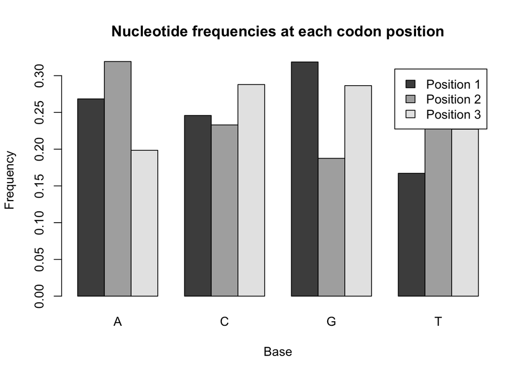

```r
# Matrix of frequencies in A, C, G, T order
freq_matrix <- rbind(
  as.numeric(pos1_freq[bases]),
  as.numeric(pos2_freq[bases]),
  as.numeric(pos3_freq[bases])
)

rownames(freq_matrix) <- c("Position 1", "Position 2", "Position 3")

barplot(
  freq_matrix,
  beside = TRUE,
  names.arg = bases,
  ylab = "Frequency",
  xlab = "Base",
  main = "Nucleotide frequencies at each codon position",
  legend.text = TRUE
)
```